# Sampling FRI signals with variable width

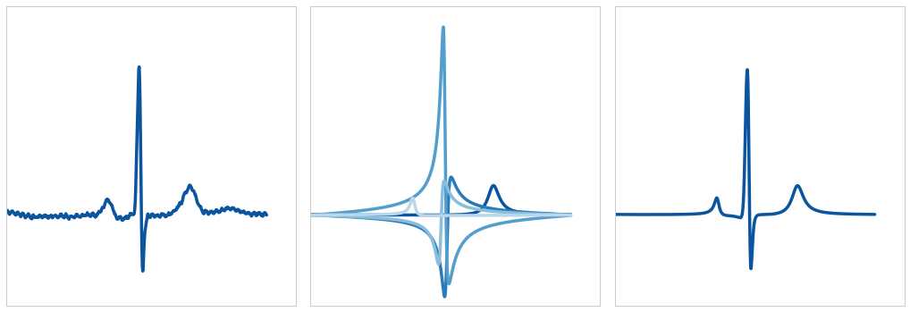

```python
import matplotlib as mpl
import matplotlib.pyplot as plt
import seaborn as sns
import numpy as np

sns.set_palette('Blues_r')
sns.set_context("notebook")
sns.set_style("whitegrid")

sns.set_context("notebook", font_scale=1.5, rc={"lines.linewidth": 3.5})

from numpy import genfromtxt

def plot_ecg_signals(indices, legend=True):

    data_ecg = genfromtxt('data/ecg.dat', delimiter=',')
    data_fri = genfromtxt('data/fri.dat', delimiter=',')

    time = data_fri[:,0]
    ecg  = data_ecg[:,1]
    fri  = data_fri[:,1:]

    fig = plt.figure(figsize=(18, 6), dpi=300)
    plt.subplots_adjust(hspace = 0.05, wspace = 0.05)
    ax1 = fig.add_subplot(131)
    ax2 = fig.add_subplot(132)
    ax3 = fig.add_subplot(133)

    ax1.plot(time, ecg)
    ax1.axes.get_xaxis().set_ticks([])
    ax1.axes.get_yaxis().set_ticks([0])
    ax1.set_ylim(-1.3,3)

    for k in indices:
        ax2.plot(time, fri[:,k])

    ax2.axes.get_xaxis().set_ticks([])
    ax2.axes.get_yaxis().set_ticks([0])
    ax2.set_ylim(-1.3,3)

    ax3.plot(time, np.sum(fri[:,:np.max(indices)+1],1))
    ax3.axes.get_xaxis().set_ticks([])
    ax3.set_ylim(-1.3,3)

    if(legend):
        ax1.axes.get_yaxis().set_ticks([0])
        ax2.axes.get_yaxis().set_ticks([0])
        ax3.axes.get_yaxis().set_ticks([0])

        ax1.set_title('Original signal', fontsize=25)
        ax2.set_title('VPW-FRI decomposition', fontsize=25)
        ax3.set_title('Estimated signal', fontsize=25)
    else:
        ax1.axes.get_yaxis().set_ticks([])
        ax2.axes.get_yaxis().set_ticks([])
        ax3.axes.get_yaxis().set_ticks([])

plot_ecg_signals(range(5),legend=False)
```

Gilles Baechler  
Laboratory of Audiovisual Communications (LCAV), EPFL

23 November 2015

## Motivation

- Atoms of FRI sampling are weighted Diracs
- Change pulse shape by changing the sampling kernel

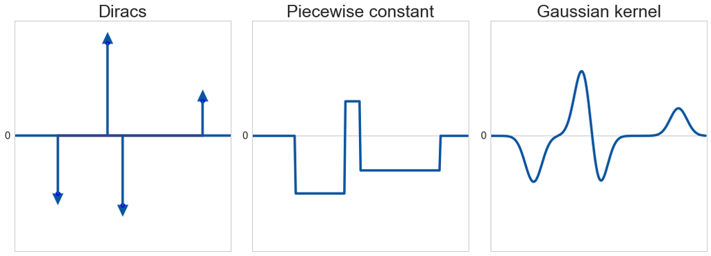

```python
def plot_atoms_fri():

    N = 200
    K = 4

    tks = np.array([0.2, 0.43, 0.5, 0.87])
    cks = np.array([-0.5, 0.8, -0.6, 0.3])

    time = np.arange(N)/np.double(N)

    fig = plt.figure(figsize=(18, 6), dpi=300)

    plt.subplots_adjust(hspace = 0.05, wspace = 0.1)
    ax1 = fig.add_subplot(131)
    ax2 = fig.add_subplot(132)
    ax3 = fig.add_subplot(133)

    steps = np.zeros(N)
    for k in np.arange(K):
        steps[np.int(N*tks[k])] = cks[k]

    ax1.stem(tks, cks, '#0b559f')
    for k in np.arange(K):
        ax1.arrow(tks[k], 0.0, 0.0, cks[k], head_width=0.05, head_length=0.1, fc='#0b559f', ec='#0b559f')
    ax1.plot(time, np.zeros(N))
    #ax1.setp(baseline, 'color','r', 'linewidth', 2)
    #ax1.plot(time, steps, linestyle='steps')
    ax1.axes.get_xaxis().set_ticks([])
    ax1.axes.get_yaxis().set_ticks([0])
    ax1.set_ylim(-1.3,3)

    ax2.plot(time, np.cumsum(steps))
    ax2.axes.get_xaxis().set_ticks([])
    ax2.axes.get_yaxis().set_ticks([0])
    ax2.set_ylim(-1.3,3)

    gauss = np.zeros(N)
    for k in np.arange(K):
        gauss = gauss + 2*cks[k]*np.exp(-(time-tks[k])**2/0.003)/sqrt(2*pi)

    ax3.plot(time, gauss)
    ax3.axes.get_xaxis().set_ticks([])
    ax3.set_ylim(-1.3,3)

    ax1.axes.get_yaxis().set_ticks([0])
    ax2.axes.get_yaxis().set_ticks([0])
    ax3.axes.get_yaxis().set_ticks([0])
    ax1.axes.set_ylim(-1,1)
    ax2.axes.set_ylim(-1,1)
    ax3.axes.set_ylim(-1,1)

    ax1.set_title('Diracs', fontsize=25)
    ax2.set_title('Piecewise constant', fontsize=25)
    ax3.set_title('Gaussian kernel', fontsize=25)

plot_atoms_fri()
```

## Motivation

- Several signals contain pulses with variable width

### Examples

- Electrocardiogram (ECG) signals

[figure not shown]

- Bidirectional reflectance distribution function (BRDF)

## Motivation

- Several signals contain pulses with variable width

### Examples

- Electrocardiogram (ECG) signals

[figure not shown]

- Bidirectional reflectance distribution function (BRDF)

## Outline

- Finite rate of innovation signals
- Adding width to Diracs
- Application: ECG sampling and compression
- Generalization to 2D
- Simulations
- Conclusion and future work

## FRI signals

- $\tau$-Periodic stream of $K$ Diracs

  ${\scriptsize \begin{align*} x(t) = \sum_{n \in \mathbb{Z}} \sum_{k = 0}^{K-1} c_k \delta (t-t_k-n \tau) \end{align*} }$
- Fourier series coefficients

  ${\scriptsize \begin{align*} X[m] = \frac{1}{\tau} \sum_{k=0}^{K-1} c_k e^{- \frac{2\pi}{ \tau }i t_k m}, \qquad m \in \mathbb{Z} \end{align*} }$
- Rate of innovation of $x(t)$ is $\rho = \frac{2K}{\tau}$

\* M. Vetterli, P. Marziliano, and T. Blu, “Sampling Signals with Finite Rate of Innovation,” IEEE Transactions on Signal Processing, vol. 17, no. 6, pp. 1417–1428, 2002.

## FRI signals

> **Theorem**

> The signal $X[m] = \sum_{k=0}^{K-1}c_k u_k^m$ is annihilated by the filter

> $${\small A(z) = \sum_{k=0}^{K-1} A[k]z^{-k} = \prod_{k=1}^{K}(1-u_k z^{-1}), }$$

> where $\{ u_k\}_{k=0}^{K-1}$ are the roots of the filter.

\* M. Vetterli, P. Marziliano, and T. Blu, “Sampling Signals with Finite Rate of Innovation,” IEEE Transactions on Signal Processing, vol. 17, no. 6, pp. 1417–1428, 2002.

### How to find the annihilating filter coefficients?

- Solve $(\boldsymbol{A} \ast \boldsymbol{X})[m] = \boldsymbol{0}$

  ${\small \begin{align*} \begin{bmatrix} X[0] & \dots & X[-K+1]\\ X[1] & \dots & X[-K+2]\\ \vdots & \ddots & \vdots\\ X[K-1] & \dots & X[0] \end{bmatrix} \begin{bmatrix} A[1]\\ A[2]\\ \vdots\\ A[K] \end{bmatrix} = -\begin{bmatrix} X[1]\\ X[2]\\ \vdots\\ X[K] \end{bmatrix} \end{align*} }$
- Compute the roots $u_k$ of the filter

### Estimation of the parameters

- Recover Diracs locations as $t_k = -\frac{\tau \angle u_k}{2 \pi}$
- Find $\{c_k\}_{k=0}^{K-1}$ by solving a linear system of equations

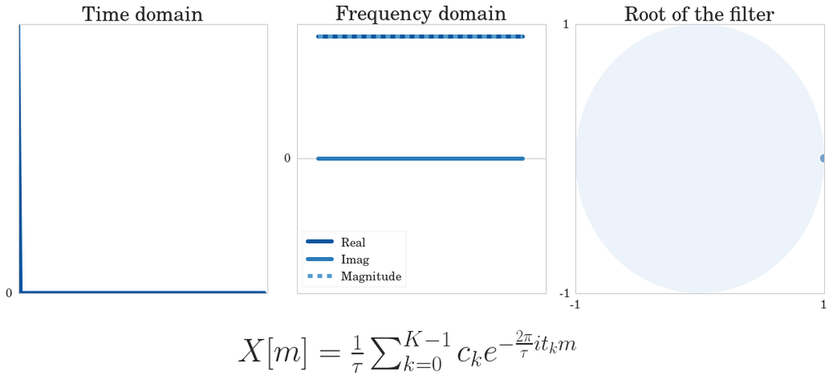

```python
from ipywidgets import interact
import numpy as np
import matplotlib as mpl
import matplotlib.pyplot as plt
import seaborn as sns
from functools import partial
from matplotlib import rc

sns.set_context("notebook", font_scale=1.5, rc={"lines.linewidth": 5.0})

def fri_time(time, tk, rk, ck):
    if(rk <= 0.0):
        signal = zeros(len(time))
        signal[np.where(time==tk)] = 1
        return signal
    else:
        signal1 = np.real(ck)/np.pi*rk/(np.power(time-tk,2) + rk*rk)
        signal2 = np.imag(ck)/np.pi*(time-tk)/(np.power(time-tk,2) + rk*rk)
        return (signal1+signal2)/np.max(signal1+signal2)

def fri_multiple_pulses(time, tks, rks, cks):
    signal = np.zeros(len(time))

    for k in range(len(tks)):
        signal = signal + fri_time(time, tks[k], rks[k], cks[k])

    return signal

def fri_freq(freq, tk, rk, ck):
    dk = np.imag(ck)
    ck = np.real(ck)
    return (ck + 1j*dk*np.sign(freq))*np.exp(-1j*tk*freq - rk*np.abs(freq) )

def compute_uk(tk, rk):
    return np.exp(2*pi*( -1j*tk - rk))

def plot_signal(tk, rk, dk):

    N = 100.0

    ck = (1.0 + 1j*dk)/sqrt(1.0+dk**2)

    fig = plt.figure(figsize=(18, 6), dpi=300)
    plt.subplots_adjust(wspace = 0.12)
    ax1 = fig.add_subplot(131)
    ax2 = fig.add_subplot(132)
    ax3 = fig.add_subplot(133)

    t = np.arange(N)/N
    freq = np.fft.fftshift(np.fft.fftfreq(int(N), 1.0/N))
    spectrum = fri_freq(freq, tk, rk, ck)
    uk = compute_uk(tk,rk)

    ax1.plot(t, fri_time(t, tk, rk, ck))
    ax1.axes.get_xaxis().set_ticks([])
    ax1.axes.get_yaxis().set_ticks([0])

    ax2.plot(freq, np.real(spectrum), label='Real', )
    ax2.plot(freq, np.imag(spectrum), label='Imag')
    ax2.plot(freq, np.abs(spectrum), '--', label='Magnitude')
    ax2.set_ylim(-1.1,1.1)
    legend= ax2.legend(loc=3, frameon=True)
    frame = legend.get_frame().set_facecolor('white')
    ax2.axes.get_xaxis().set_ticks([])
    ax2.axes.get_yaxis().set_ticks([0])

    unit_circle = plt.Circle((0,0) ,1.0,color='#dbe9f6', alpha=0.5)
    ax3.scatter(np.real(uk), np.imag(uk), color='#0b559f', s=100)
    ax3.add_artist(unit_circle)
    ax3.set_xlim(-1,1)
    ax3.set_ylim(-1,1)
    ax3.axes.get_xaxis().set_ticks([-1,1])
    ax3.axes.get_yaxis().set_ticks([-1,1])

    ax1.set_title('Time domain', fontsize=25)
    ax2.set_title('Frequency domain', fontsize=25)
    ax3.set_title('Root of the filter', fontsize=25)

    plt.rc('text', usetex=True)
    plt.rc('font', family='serif')
    plt.suptitle(r"$X[m] = \frac{1}{\tau} \sum_{k=0}^{K-1} (c_k - i d_k \operatorname{sgn}(m) ) e^{-\frac{2\pi}{\tau} (i t_k m + r_k |m| )}$", fontsize=35, x=0.5, y=0.0);

def plot_signal_rk_0(tk):
    plot_signal(tk, 0.0, 0.0)
    plt.suptitle(r"$X[m] = \frac{1}{\tau} \sum_{k=0}^{K-1} c_k e^{- \frac{2\pi}{ \tau }i t_k m}$", fontsize=40, x=0.5, y=0.0)

def plot_signal_ck_0(tk, rk):
    plot_signal(tk, rk, 0.0)
    plt.suptitle(r"$X[m] = \frac{1}{\tau} \sum_{k=0}^{K-1} c_k e^{- \frac{2\pi}{ \tau }(i t_k m + r_k |m|)}$", fontsize=40, x=0.5, y=0.0)

interact(plot_signal_rk_0, tk=(0,1,1.0/100));
```

### Adding width to Diracs

- *What happens if we move the root inside the unit circle?* Let $u_k = e^{-\frac{2\pi}{\tau} (i t_k + r_k)}$

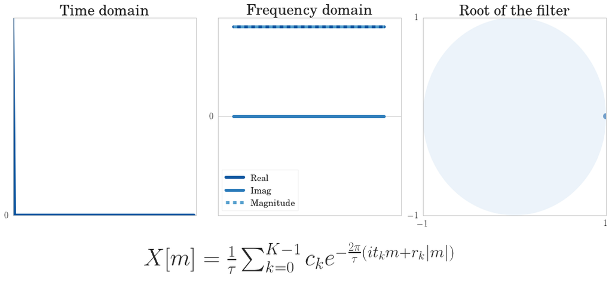

```python
interact(plot_signal_ck_0, tk=(0,1,1.0/100), rk=(0,0.25,0.01));
```

### Adding asymmetry to pulses

- *What if the amplitude $c_k$ is complex?* Let $ck = 1 + i d_k$

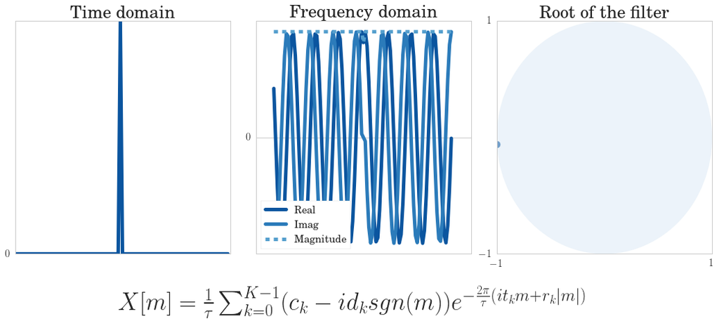

```python
interact(plot_signal, tk=(0.0, 1.0, 1.0/100), rk=(0,0.25,0.01), dk=(0.0,1.0,1.0/100));
```

## Variable pulse width (VPW)-FRI

- Continuous-time formula

  ${\scriptsize \begin{align*} x(t) = \sum_{n \in \mathbb{Z}} \left( \sum_{k = 0}^{K-1} \frac{c_k}{\pi} \frac{r_k}{(r_k^2 + (t-t_k-n\tau)^2)} + \sum_{k = 0}^{K-1} \frac{d_k}{\pi} \frac{t-t_k-n\tau}{(r_k^2 + (t-t_k-n\tau)^2)} \right) \end{align*} }$
- Fourier series coefficients

  ${\scriptsize \begin{align*} X[m] = \frac{1}{\tau} \sum_{k=0}^{K-1} (c_k - i d_k \operatorname{sgn}(m) ) e^{-\frac{2\pi}{\tau} (i t_k m + r_k |m| )}, \qquad m \in \mathbb{Z} \end{align*} }$
- Rate of innovation of $x(t)$ is $\rho = \frac{4K}{\tau}$
- Parameters estimation as in the classical case (with $m \geq 0$)

### Denoising

- ESPRIT (matrix-pencil)
- Cadzow
- IQML

\* R. Roy and T. Kailath, "ESPRIT - Estimation of Signal Parameters via Rotational Invariance Techniques," IEEE Transactions on Acoustics, Speech, and Signal Processing, vol. 37, no. 7, pp. 984-995, 1989.  
\* J. A. Cadzow, "Signal Enhancement - a Composite Property Mapping Algorithm," IEEE Transactions on Acoustics, Speech, and Signal Processing, vol. 36, no. I, 1988.

### Cadzow denoising

- Build the Toeplitz matrix $\boldsymbol{T}$ from $X[m]$

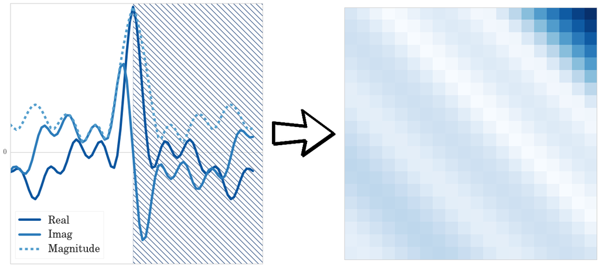

```python
from scipy import linalg
import matplotlib.gridspec as gridspec
import matplotlib.patches as patches
import matplotlib.image as mpimg


#builds a Toeplitz matrix from a vector
def to_toeplitz(coefficients, n_col):
    tc = coefficients[(n_col-1):]
    tr = coefficients[np.arange(n_col-1, -1, -1)]

    return linalg.toeplitz(tc, tr)

def plot_matrix(matrix):
    gs = gridspec.GridSpec(1, 3, width_ratios=[1, 0.25, 1])

    fig = plt.figure(figsize=(17, 7.1), dpi=300)
    fig.patch.set_facecolor('white')
    plt.subplots_adjust(wspace = 0.05)

    mat1_ax = plt.subplot(gs[0,0])
    mat1_ax.matshow(np.abs(matrix), cmap=plt.cm.Blues)
    plt.xticks([])
    plt.yticks([])


def plot_spectrum_matrix(spectrum, matrix, show_grid=False):


    gs = gridspec.GridSpec(1, 3, width_ratios=[1, 0.25, 1])

    fig = plt.figure(figsize=(22.5, 10), dpi=300)
    fig.patch.set_facecolor('white')
    plt.subplots_adjust(wspace = 0.05)

    toeplitz_ax = plt.subplot(gs[0,2])
    toeplitz_ax.matshow(np.abs(matrix), cmap=plt.cm.Blues)
    plt.xticks([])
    plt.yticks([])

    ax2 = plt.subplot(gs[0,0])
    ax2.plot(np.real(spectrum), label='Real')
    ax2.plot(np.imag(spectrum), label='Imag')
    ax2.plot(np.abs(spectrum), '--', label='Magnitude')
    legend= ax2.legend(loc=3, frameon=True, fontsize=22)
    frame = legend.get_frame().set_facecolor('white')
    ax2.axes.get_xaxis().set_ticks([])
    ax2.axes.get_yaxis().set_ticks([0])

    if(show_grid):
        p = patches.Rectangle((39, -50), 50, 100, hatch='\\\\', fill=False, edgecolor='#08306b')
        ax2.add_patch(p)


    #draw arrow
    arrow_ax = plt.subplot(gs[0,1])
    arrow_ax.imshow(mpimg.imread('figures/arrow2.png'))
    arrow_ax.axis('off')


N = 39.0
n_cols = 20

K = 4
tks = [0.1, 0.3, 0.45, 0.73]
rks = [0.01, 0.025, 0.15, 0.015]
cks = [1, 0.6, 2, 0.3+0.3j]

#freq = np.fft.fftfreq(int(2*N), 1/N)[:N]
freq = np.fft.fftshift(np.fft.fftfreq(int(2*N), 1/(2.0*N)))

spectrum = np.zeros(int(2*N))
for k in range(len(tks)):
    spectrum = spectrum + fri_freq(freq, tks[k], rks[k], cks[k])

matrix = to_toeplitz(spectrum[int(N):], n_cols)

plot_spectrum_matrix(spectrum, matrix, show_grid=True)
```

### Cadzow denoising

- When the Fourier measurements $\tilde{X}[m]$ are noisy...

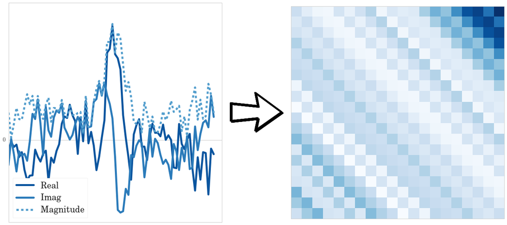

```python
noise_power = 0.5

noisy_spectrum = spectrum + noise_power*np.random.normal(0.0,1.0,len(spectrum)) + noise_power*1j*np.random.normal(0.0,1.0,len(spectrum))

noisy_matrix = to_toeplitz(noisy_spectrum[int(N):], n_cols)

plot_spectrum_matrix(noisy_spectrum, noisy_matrix)
```

### Cadzow denoising

- Low rank approximation of $\tilde{\boldsymbol{T}}$

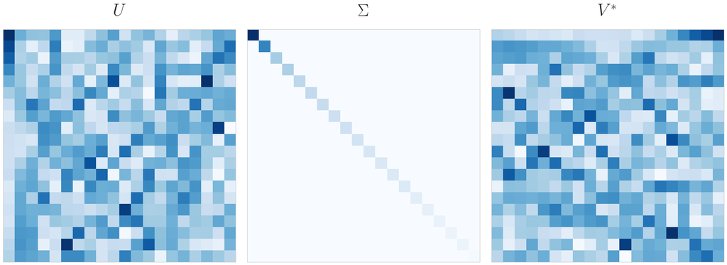

```python
def plot_svd(U,S,V):

    fig = plt.figure(figsize=(30, 10), dpi=300)
    plt.subplots_adjust(wspace = 0.05)
    ax1 = fig.add_subplot(131)
    ax2 = fig.add_subplot(132)
    ax3 = fig.add_subplot(133)

    plt.rc('text', usetex=True)
    plt.rc('font', family='serif')

    ax1.matshow(np.abs(U), cmap=plt.cm.Blues)
    ax1.axes.get_xaxis().set_ticks([])
    ax1.axes.get_yaxis().set_ticks([])
    ax1.set_title(r"$\boldsymbol{U}$", fontsize=40)

    ax2.matshow(np.abs(np.diag(S)), cmap=plt.cm.Blues)
    ax2.axes.get_xaxis().set_ticks([])
    ax2.axes.get_yaxis().set_ticks([])
    ax2.set_title(r"$\boldsymbol{\Sigma}$", fontsize=40)

    ax3.matshow(np.abs(V), cmap=plt.cm.Blues)
    ax3.axes.get_xaxis().set_ticks([])
    ax3.axes.get_yaxis().set_ticks([])
    ax3.set_title(r"$\boldsymbol{V}^*$", fontsize=40)


U,S,V = np.linalg.svd(noisy_matrix)

plot_svd(U,S,V)
```

### Cadzow denoising

- Low rank approximation of $\tilde{\boldsymbol{T}}$

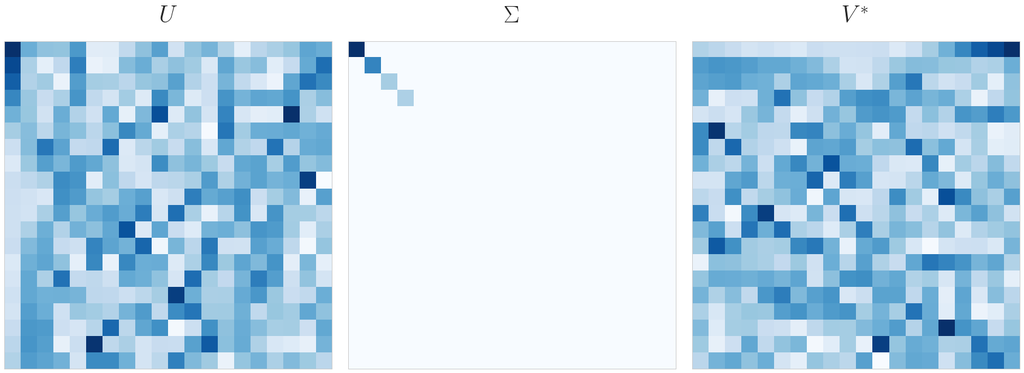

```python
S[K:] = 0.0

plot_svd(U,S,V)
```

### Cadzow denoising

- Low rank approximation of $\tilde{\boldsymbol{T}}$

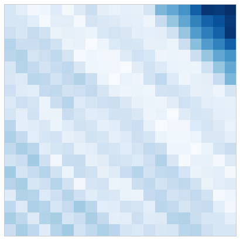

```python
matrix_K = np.dot(np.dot(U,np.diag(S)), V)

plot_matrix(matrix_K)
```

### Cadzow denoising

- Make $\tilde{\boldsymbol{T}}$ Toeplitz by averaging diagonal entries

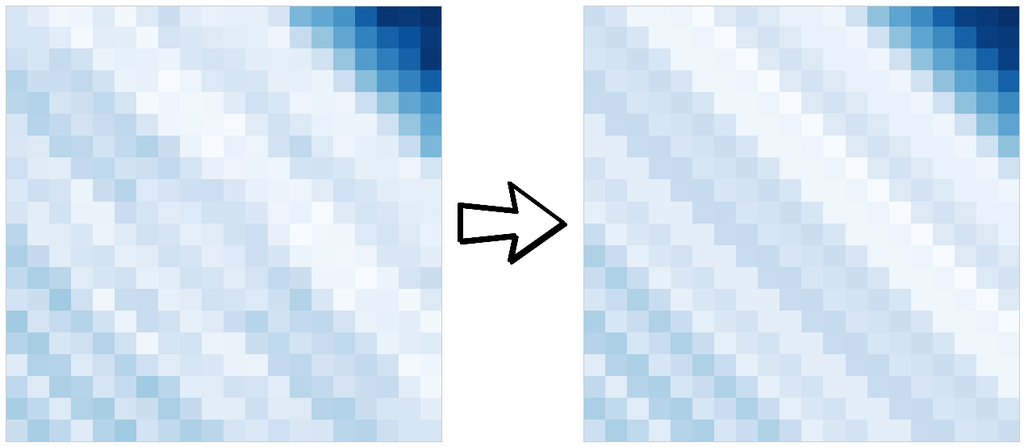

```python
#Approximate a matrix with a Toeplitz matrix
def toeplitz_projection(mat):

    rows, cols = mat.shape
    toeplitz = np.zeros(mat.shape, dtype=np.complex_)
    row_id, col_id = np.indices(mat.shape)

    for offset in (range(-rows+1,0) + range(cols)):
        val = np.mean(mat.diagonal(offset))

        rid = row_id.diagonal(offset)
        cid = col_id.diagonal(offset)

        toeplitz[rid, cid] = val*np.ones(len(mat.diagonal(offset)))

    return toeplitz

def plot_2_matrices(matrix1, matrix2):


    gs = gridspec.GridSpec(1, 3, width_ratios=[1, 0.25, 1])

    fig = plt.figure(figsize=(22.5, 10), dpi=300)
    fig.patch.set_facecolor('white')
    plt.subplots_adjust(wspace = 0.05)

    mat1_ax = plt.subplot(gs[0,0])
    mat1_ax.matshow(np.abs(matrix1), cmap=plt.cm.Blues)
    plt.xticks([])
    plt.yticks([])

    mat2_ax = plt.subplot(gs[0,2])
    mat2_ax.matshow(np.abs(matrix2), cmap=plt.cm.Blues)
    plt.xticks([])
    plt.yticks([])

    #draw arrow
    arrow_ax = plt.subplot(gs[0,1])
    arrow_ax.imshow(mpimg.imread('figures/arrow2.png'))
    arrow_ax.axis('off')



matrix_T = toeplitz_projection(matrix_K)

plot_2_matrices(matrix_K, matrix_T)
```

### Simulation

- $K = 3, \tau = 1, \rho = 12$
- We use $20$ Fourier coefficients

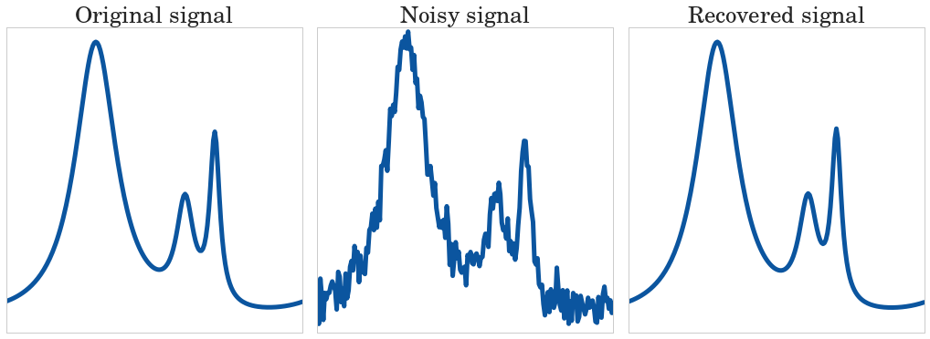

```python
from fri import *

def format_1D(ax, title, label=''):
    ax.set_title(title, fontsize=25)
    ax.axes.get_xaxis().set_ticks([])
    ax.axes.get_yaxis().set_ticks([])
    ax.set_ylabel(label, fontsize=25)

def plot_fri_noise(snr):

    gs = gridspec.GridSpec(1, 3)

    tk  = np.array([ 0.6, 0.7, 0.3])
    rk  = np.array([ 0.035,  0.02,   0.085])
    ck  = np.array([ 0.75,  0.7,  5.0])
    T = 1.0
    K = 3

    #Standard VPW
    N = 200.0

    vpw_fri = VPW_FRI(tk, rk, ck, T)
    time = np.linspace(0, T, N)
    frequencies = np.fft.fftfreq(int(N), T/N)
    omega = 2*np.pi*frequencies/T
    signal = vpw_fri.evaluate_time_domain(time)
    spectrum = vpw_fri.evaluate_Fourier_domain(omega)

    fig = plt.figure(figsize=(18, 6), dpi=300)
    fig.patch.set_facecolor('white')
    plt.subplots_adjust(hspace = 0.01, wspace = 0.05)

    signal = np.real(np.fft.ifft(spectrum))

    signal_power = np.linalg.norm(signal)**2/N
    noise_power  = signal_power/np.power(10, snr/10.0)

    signal_noisy   = signal + np.random.normal(0,sqrt(noise_power),int(N))
    spectrum_noisy = np.fft.fft(signal_noisy)

    fri_estimated = FRI_estimator(K, T, T/N, T/N).estimate_parameters(spectrum_noisy[:20])
    spectrum_estimated = fri_estimated.evaluate_Fourier_domain(omega)

    classical_vpw = plt.subplot(gs[0,0])
    classical_vpw.plot(time, signal)
    format_1D(classical_vpw, 'Original signal')
    classical_vpw.set_ylim(0, 1.05*np.max(signal))

    recovered_vpw = plt.subplot(gs[0,1])
    recovered_vpw.plot(time, signal_noisy)
    format_1D(recovered_vpw, 'Noisy signal')
    recovered_vpw.set_ylim(0, 1.05*np.max(signal))

    signal_estimated = np.real(np.fft.ifft(spectrum_estimated))
    mse = np.mean(np.power(signal-signal_estimated, 2.0))
    snr_recovered = 10*np.log10(signal_power/(np.linalg.norm(signal-signal_estimated)**2/N))
    #print(snr_recovered)

    recovered_vpw = plt.subplot(gs[0,2])
    recovered_vpw.plot(time, signal_estimated)
    format_1D(recovered_vpw, 'Recovered signal')
    recovered_vpw.set_ylim(0, 1.05*np.max(signal))

interact(plot_fri_noise, snr=(-10,50));
```

### Other types of kernels

- Exponential reproducing kernels: $\sum_{n \in \mathbb{Z}} c_{m,n} \varphi (t-n) = e^{\alpha_m t}$

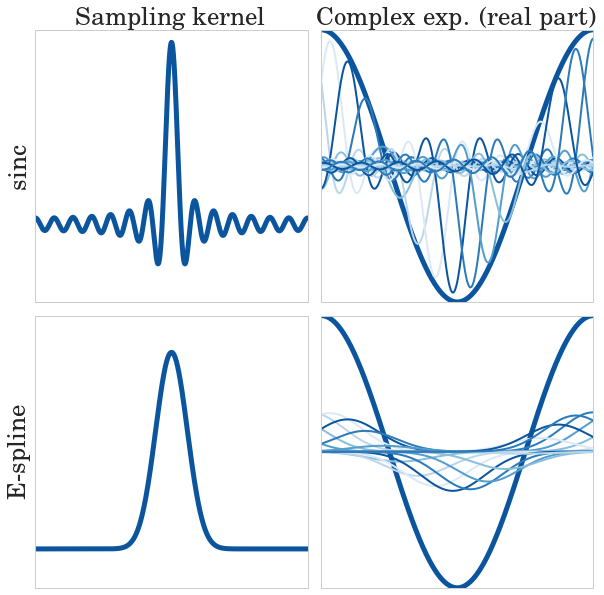

```python
def style_exp_reproduction(ax, N, title='', label=''):
    ax.set_title(title, fontsize=25)
    ax.axes.get_xaxis().set_ticks([])
    ax.axes.get_yaxis().set_ticks([])
    ax.set_ylabel(label, fontsize=25)
    ax.set_xlim(0,N)

def plot_sinc_e_spline():
    P = 30.0 #spline order
    N = P+1 #number samples
    T = 1.0  #sampling interval

    upsampling_factor = 100.0
    T2 = T/upsampling_factor
    N2 = upsampling_factor*N

    omega = 2*np.pi/N*np.arange(N)
    omega_fine = np.pi/N2*np.arange(-N2, N2)
    omega_fine_for_time = 2*pi/N*np.arange(N2)

    time = np.arange(N)
    time_fine = np.arange(upsampling_factor*N-1)/upsampling_factor

    alpha_0 = -np.pi*P/(P+1)
    lambd = 2*np.pi/(P+1)

    if (P%2 == 1):
        alpha_0 = -2*np.pi*P/(P+1)
        lambd = 4*np.pi/(P+1)
    omega_m = alpha_0 + lambd*np.arange(P+1)
    alpha_m = 1j*omega_m

    e_spline_fourier_at_omega_m = np.ones(P+1, dtype=np.complex)
    e_spline_fourier = np.ones(N, dtype=np.complex)
    e_spline_fourier_fine = np.ones(2*N2, dtype=np.complex);
    e_spline_fourier_fine_for_time = np.ones(N2, dtype=np.complex)

    sinc_fourier_at_omega_m = np.ones(P+1)
    sinc_fourier = np.ones(N)
    sinc_fourier_fine = np.ones(2*N2, dtype=np.complex);
    sinc_fourier_fine_for_time = np.zeros(int(N2))
    sinc_fourier_fine_for_time[np.arange(int(N/2))] = 1.0

    for m in np.arange(int(P+1)):

        idx = np.setdiff1d(np.arange(int(P+1)), m)
        e_spline_fourier_at_omega_m[idx] = e_spline_fourier_at_omega_m[idx]*(1.0-np.exp(alpha_m[m]-1j*omega_m[idx]))/(1j*omega_m[idx]-alpha_m[m])
        e_spline_fourier                 = e_spline_fourier*(1.0-np.exp(alpha_m[m]-1j*omega))/(1j*omega-alpha_m[m])
        e_spline_fourier_fine            = e_spline_fourier_fine*(1.0-np.exp(alpha_m[m]-1j*omega_fine))/(1j*omega_fine-alpha_m[m])
        e_spline_fourier_fine_for_time   = e_spline_fourier_fine_for_time*(1.0-np.exp(alpha_m[m]-1j*omega_fine_for_time))/(1j*omega_fine_for_time-alpha_m[m])

    e_spline = np.fft.irfft(e_spline_fourier, n=np.int(N))
    e_spline_fine = 1/T2*np.fft.irfft(e_spline_fourier_fine_for_time, n=np.int(N2))

    sinc = np.fft.fftshift(np.fft.irfft(sinc_fourier, n=np.int(N)))
    sinc =np.fft.irfft(sinc_fourier, n=np.int(N))
    sinc_fine = 1/T2*np.fft.fftshift(np.fft.irfft(sinc_fourier_fine_for_time, n=np.int(N2)))
    #sinc_fine = 1/T2*np.fft.irfft(sinc_fourier_fine_for_time, n=np.int(N2))

    gs = gridspec.GridSpec(2,2)

    fig = plt.figure(figsize=(10,10), dpi=300)
    fig.patch.set_facecolor('white')

    plt.subplots_adjust(wspace = 0.05, hspace=0.05)

    spline_ax = plt.subplot(gs[1,0])
    spline_ax.plot(e_spline_fine)
    style_exp_reproduction(spline_ax, N2, label='E-spline')

    sinc_ax = plt.subplot(gs[0,0])
    sinc_ax.plot(sinc_fine)
    style_exp_reproduction(sinc_ax, N2, label='sinc', title='Sampling kernel')

    V = np.exp(np.outer(alpha_m, np.arange(N)))
    exponentials = np.exp(np.outer(alpha_m, time_fine));
    Phi1 = zeros((np.int(N),np.int(N2)), dtype=np.double)
    Phi1[0,:] = e_spline_fine
    Phi2 = zeros((np.int(N),np.int(N2)), dtype=np.double)
    Phi2[0,:] = sinc_fine
    for n in np.arange(1,int(N)):
        Phi1[n,:] = np.roll(e_spline_fine, int(n*upsampling_factor))
        Phi2[n,:] = np.roll(sinc_fine, int(n*upsampling_factor))

    C1 = np.dot(np.diag(1.0/e_spline_fourier_at_omega_m),V)

    C2 = np.dot(np.diag(1.0/sinc_fourier_at_omega_m),V)

    m = 13

    spline_repr = plt.subplot(gs[1,1])
    spline_repr.plot(np.real(exponentials[m ,:int(N2/2)]))
    summation1 = np.zeros(np.int(N2))

    sinc_repr = plt.subplot(gs[0,1])
    sinc_repr.plot(np.real(exponentials[m ,:int(N2/2)]))
    summation2 = np.zeros(np.int(N2))

    for p in np.arange(np.int(N)):
        spline_repr.plot(np.real(C1[m,p]*Phi1[p,:int(N2/2)]), linewidth=2.0)
        sinc_repr.plot(np.real(C2[m,p]*Phi2[p,:int(N2/2)]), linewidth=2.0)

    style_exp_reproduction(spline_repr, int(N2/2))
    style_exp_reproduction(sinc_repr, int(N2/2), title='Complex exp. (real part)')





plot_sinc_e_spline()
```

\* P. L. Dragotti, M. Vetterli, and T. Blu, "Sampling Moments and Reconstructing Signals of Finite Rate of Innovation: Shannon meets Strang-Fix," IEEE Transactions on Signal Processing, vol. 55, no. 5, pp. 1741-1757, 2007.  
\* Uriguen, Jose Antonio, Thierry Blu, and Pier Luigi Dragotti. "FRI sampling with arbitrary kernels."IEEE Transactions on Signal Processing, 61.21 (2013): 5310-5323.

### Application to ECG signal compression

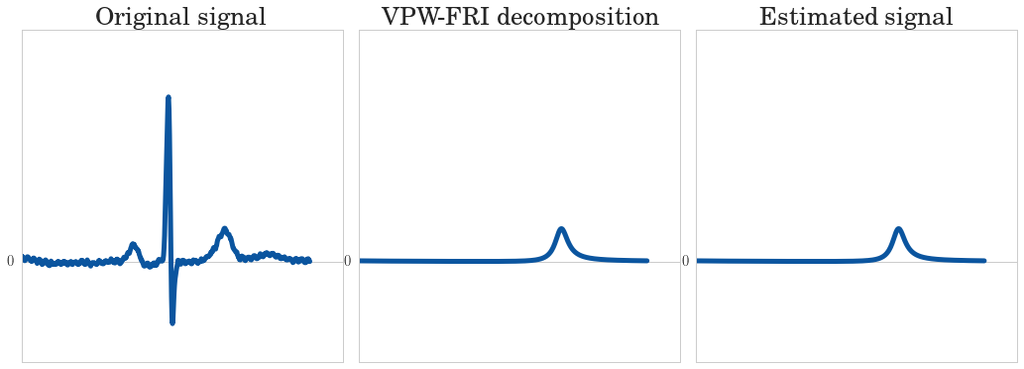

```python
plot_ecg_signals([0], True)
```

\* A.L. Goldberger, L.A.N. Amaral, L. Glass, J.M. Hausdorff, P.C. Ivanov, R.G. Mark, J.E. Mietus, G.B. Moody, C.-K. Peng, H.E. Stanley, "PhysioBank, PhysioToolkit, and PhysioNet: Components of a New Research Resource for Complex Physiologic Signals".

### Application to ECG signal compression

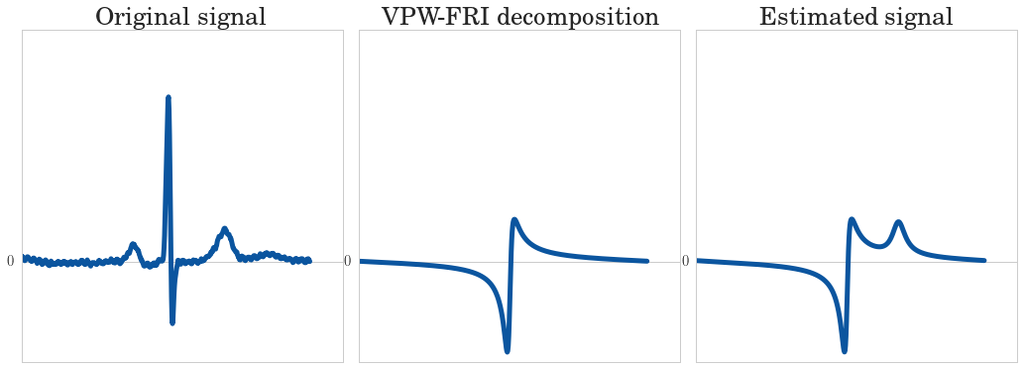

```python
plot_ecg_signals([1], True)
```

\* A.L. Goldberger, L.A.N. Amaral, L. Glass, J.M. Hausdorff, P.C. Ivanov, R.G. Mark, J.E. Mietus, G.B. Moody, C.-K. Peng, H.E. Stanley, "PhysioBank, PhysioToolkit, and PhysioNet: Components of a New Research Resource for Complex Physiologic Signals".

### Application to ECG signal compression

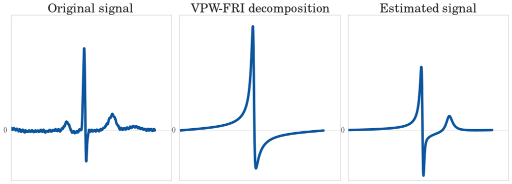

```python
plot_ecg_signals([2], True)
```

\* A.L. Goldberger, L.A.N. Amaral, L. Glass, J.M. Hausdorff, P.C. Ivanov, R.G. Mark, J.E. Mietus, G.B. Moody, C.-K. Peng, H.E. Stanley, "PhysioBank, PhysioToolkit, and PhysioNet: Components of a New Research Resource for Complex Physiologic Signals".

### Application to ECG signal compression

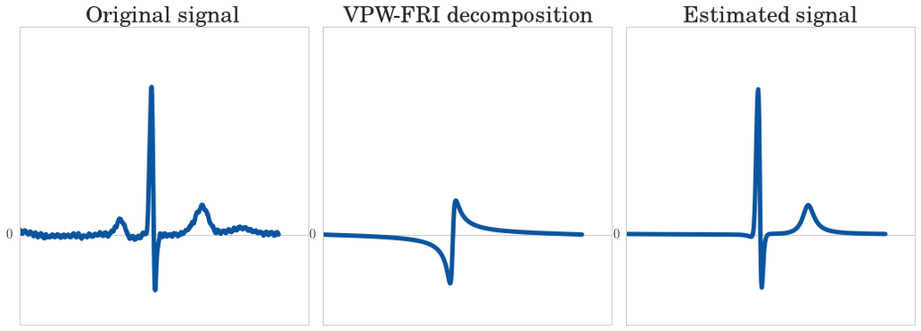

```python
plot_ecg_signals([3], True)
```

\* A.L. Goldberger, L.A.N. Amaral, L. Glass, J.M. Hausdorff, P.C. Ivanov, R.G. Mark, J.E. Mietus, G.B. Moody, C.-K. Peng, H.E. Stanley, "PhysioBank, PhysioToolkit, and PhysioNet: Components of a New Research Resource for Complex Physiologic Signals".

### Application to ECG signal compression

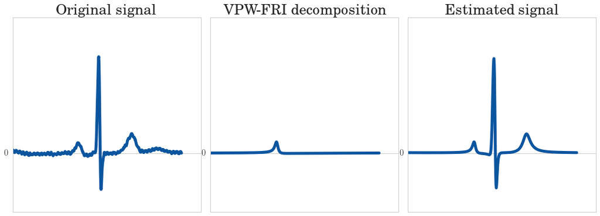

```python
plot_ecg_signals([4], True)
```

\* A.L. Goldberger, L.A.N. Amaral, L. Glass, J.M. Hausdorff, P.C. Ivanov, R.G. Mark, J.E. Mietus, G.B. Moody, C.-K. Peng, H.E. Stanley, "PhysioBank, PhysioToolkit, and PhysioNet: Components of a New Research Resource for Complex Physiologic Signals".

### Application to ECG signal compression

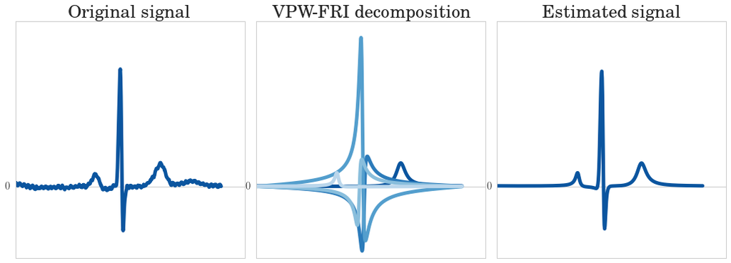

```python
plot_ecg_signals(range(5), True)
```

\* A.L. Goldberger, L.A.N. Amaral, L. Glass, J.M. Hausdorff, P.C. Ivanov, R.G. Mark, J.E. Mietus, G.B. Moody, C.-K. Peng, H.E. Stanley, "PhysioBank, PhysioToolkit, and PhysioNet: Components of a New Research Resource for Complex Physiologic Signals".

## Generalization to 2D

```python
from mpl_toolkits.mplot3d import axes3d

def format_2D(ax, title='', label=''):
    ax.set_xticks([])
    ax.set_yticks([])
    ax.set_zticks([])
    ax.w_xaxis.set_pane_color((1.0, 1.0, 1.0, 1.0))
    ax.w_yaxis.set_pane_color((1.0, 1.0, 1.0, 1.0))
    ax.w_zaxis.set_pane_color((1.0, 1.0, 1.0, 1.0))
    tmp_planes = ax.zaxis._PLANES
    ax.zaxis._PLANES = ( tmp_planes[2], tmp_planes[3],
                     tmp_planes[0], tmp_planes[1],
                     tmp_planes[4], tmp_planes[5])
    ax.set_zlabel(label, fontsize=25)
    ax.set_title(title, fontsize=25)
```

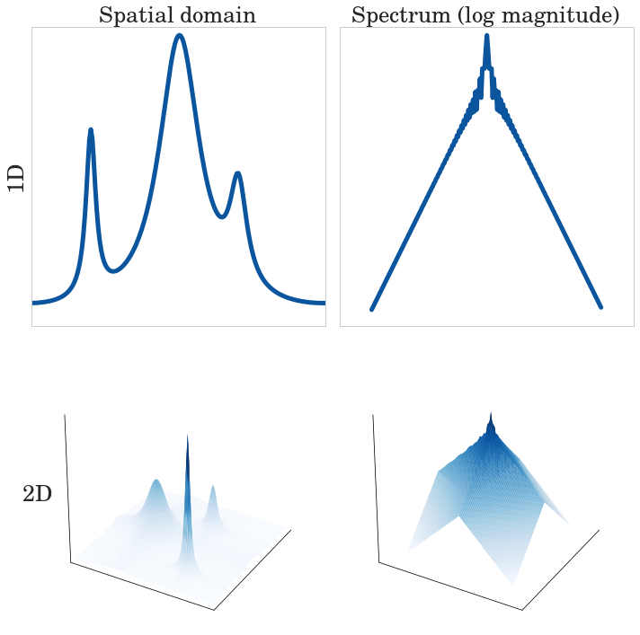

```python
from fri import *
from mpl_toolkits.mplot3d import axes3d

def plot_fri_2D(K):

    gs = gridspec.GridSpec(2, 2)

    tk2  = np.array([[ 0.6,  0.7], [ 0.7,  0.2], [ 0.3,  0.5]])
    tk = tk2[:,1]
    rk  = np.array([ 0.035,  0.02,   0.085])
    ck  = np.array([ 0.75,  0.7,  5.0])
    T = 1.0

    #Standard VPW
    N = 200.0

    vpw_fri = VPW_FRI(tk, rk, ck, T)
    time = np.linspace(0, T, N)
    frequencies = np.fft.fftfreq(int(N), T/N)
    omega = 2*np.pi*frequencies/T
    spectrum = vpw_fri.evaluate_Fourier_domain(omega)

    fig = plt.figure(figsize=(12, 12), dpi=300)
    fig.patch.set_facecolor('white')
    plt.subplots_adjust(hspace = 0.01, wspace = 0.05)

    classical_vpw_freq_ax = plt.subplot(gs[0,1])
    classical_vpw_freq_ax.semilogy(np.fft.fftshift(omega), np.fft.fftshift(np.abs(spectrum)))
    format_1D(classical_vpw_freq_ax, 'Spectrum (log magnitude)')

    classical_vpw = plt.subplot(gs[0,0])
    classical_vpw.plot(time, np.real(np.fft.ifft(spectrum))*N)
    format_1D(classical_vpw, 'Spatial domain', label='1D')

    #2D VPW, 'normal'
    M = 100.0
    N = 100.0

    vpw_fri2 = VPW_FRI_2D(tk2, rk, ck, T/M, T/N)
    y_grid, x_grid = np.meshgrid(np.linspace(0, T, N),np.linspace(0, T, M))
    f_u = 2*np.pi*np.fft.fftfreq(int(M), T/M)/T
    f_v = 2*np.pi*np.fft.fftfreq(int(N), T/N)/T
    v_grid, u_grid = np.meshgrid(np.fft.fftshift(f_v), np.fft.fftshift(f_u))
    spectrum_2D = vpw_fri2.evaluate_Fourier_domain(f_u, f_v)

    vpw_2D_freq_ax = plt.subplot(gs[1,1], projection='3d')
    vpw_2D_freq_ax.plot_surface(u_grid, v_grid, np.log(np.fft.fftshift(abs(spectrum_2D))), rstride=1, cstride=1, linewidth=0, cmap=plt.cm.Blues)
    #vpw_2D_freq_ax = plt.subplot(gs[1,1])
    #vpw_2D_freq_ax.matshow(np.log(np.fft.fftshift(abs(spectrum_2D))), cmap=plt.cm.Blues)
    format_2D(vpw_2D_freq_ax)

    vpw_2D_ifft_ax = plt.subplot(gs[1,0], projection='3d')
    vpw_2D_ifft_ax.plot_surface(x_grid, y_grid, np.real(np.fft.ifft2(spectrum_2D)), rstride=1, cstride=1, linewidth=0, cmap=plt.cm.Blues)
    #vpw_2D_ifft_ax = plt.subplot(gs[1,0])
    #vpw_2D_ifft_ax.matshow(np.real(np.fft.ifft2(spectrum_2D)), cmap=plt.cm.Blues)
    format_2D(vpw_2D_ifft_ax, label='2D')



K = 3
plot_fri_2D(K)
```

## Generalization to 2D

```python
def format_2D_images(ax, title='', label=''):
    ax.set_xticks([])
    ax.set_yticks([])
    ax.set_title(title, fontsize=25)
    ax.set_ylabel(label, fontsize=25)
```

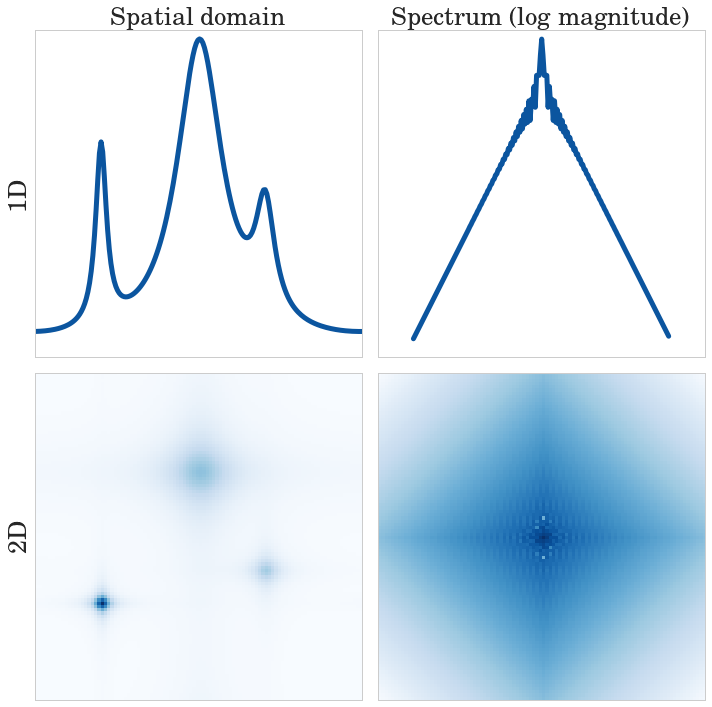

```python
def plot_fri_2D_images(K):

    gs = gridspec.GridSpec(2, 2)

    tk2  = np.array([[ 0.6,  0.7], [ 0.7,  0.2], [ 0.3,  0.5]])
    tk = tk2[:,1]
    rk  = np.array([ 0.035,  0.02,   0.085])
    ck  = np.array([ 0.75,  0.7,  5.0])
    T = 1.0

    #Standard VPW
    N = 200.0

    vpw_fri = VPW_FRI(tk, rk, ck, T)
    time = np.linspace(0, T, N)
    frequencies = np.fft.fftfreq(int(N), T/N)
    omega = 2*np.pi*frequencies/T
    signal = vpw_fri.evaluate_time_domain(time)
    spectrum = vpw_fri.evaluate_Fourier_domain(omega)

    fig = plt.figure(figsize=(12, 12), dpi=300)
    fig.patch.set_facecolor('white')
    plt.subplots_adjust(hspace = 0.05, wspace = 0.05)

    classical_vpw_freq_ax = plt.subplot(gs[0,1])
    classical_vpw_freq_ax.semilogy(np.fft.fftshift(omega), np.fft.fftshift(np.abs(spectrum)))
    format_1D(classical_vpw_freq_ax, 'Spectrum (log magnitude)')

    classical_vpw = plt.subplot(gs[0,0])
    classical_vpw.plot(time, np.real(np.fft.ifft(spectrum))*N)
    format_1D(classical_vpw, 'Spatial domain', label='1D')

    #2D VPW, 'normal'
    M = 100.0
    N = 100.0

    vpw_fri2 = VPW_FRI_2D(tk2, rk, ck, T/M, T/N)
    y_grid, x_grid = np.meshgrid(np.linspace(0, T, N),np.linspace(0, T, M))
    f_u = 2*np.pi*np.fft.fftfreq(int(M), T/M)/T
    f_v = 2*np.pi*np.fft.fftfreq(int(N), T/N)/T
    v_grid, u_grid = np.meshgrid(np.fft.fftshift(f_v), np.fft.fftshift(f_u))
    spectrum_2D = vpw_fri2.evaluate_Fourier_domain(f_u, f_v)

    vpw_2D_freq_ax = plt.subplot(gs[1,1])
    vpw_2D_freq_ax.matshow(np.log(np.fft.fftshift(abs(spectrum_2D))), cmap=plt.cm.Blues)
    format_2D_images(vpw_2D_freq_ax)

    vpw_2D_ifft_ax = plt.subplot(gs[1,0])
    vpw_2D_ifft_ax.matshow(np.real(np.fft.ifft2(spectrum_2D)), cmap=plt.cm.Blues)
    format_2D_images(vpw_2D_ifft_ax, label='2D')


plot_fri_2D_images(K)
```

## Generalization to 2D

- Spatial-domain expression

  ```
  f(x,y) = \sum_{k = 0}^{K-1} \frac{2 c_k}{\pi} \frac{r_k}{(r_k^2 + (x-x_k)^2)} \frac{r_k}{(r_k^2 + (y-y_k)^2)}
  ```

  ${\small \begin{align*} F[m,n] = \frac{1}{\tau^2} \sum_{k=0}^{K-1} c_k e^{-i \frac{2\pi}{\tau} (x_k m + y_k n)} e^{ \frac{2\pi}{\tau} r_k (|m| + |n|)}, \qquad m \in \mathbb{Z} \end{align*} }$
- Annihilate each dimension separately

### Find the good combinations of $tks$

- Combinatorial search :  
  test all $K!$ combinations

[figure not shown]

- Heuristic way :  
  assume all combinations are valid

### Find the good combinations of $tks$

- Combinatorial search :  
  test all $K!$ combinations

[figure not shown]

- Heuristic way :  
  assume all combinations are valid

### Find the good combinations of $tks$

- Combinatorial search :  
  test all $K!$ combinations

[figure not shown]

- Heuristic way :  
  assume all combinations are valid

### Find the good combinations of $tks$

- Combinatorial search :  
  test all $K!$ combinations

[figure not shown]

- Heuristic way :  
  assume all combinations are valid

### Find the good combinations of $tks$

- Combinatorial search :  
  test all $K!$ combinations

[figure not shown]

- Heuristic way :  
  assume all combinations are valid

### Find the good combinations of $tks$

- Combinatorial search :  
  test all $K!$ combinations

[figure not shown]

- Heuristic way :  
  assume all combinations are valid

### Find the good combinations of $tks$

- Combinatorial search :  
  test all $K!$ combinations

[figure not shown]

- Heuristic way :  
  assume all combinations are valid

### Find the good combinations of $tks$

- Combinatorial search :  
  test all $K!$ combinations

[figure not shown]

- 'Heuristic' approach :  
  assume all combinations are valid

### Denoising: Cadzow

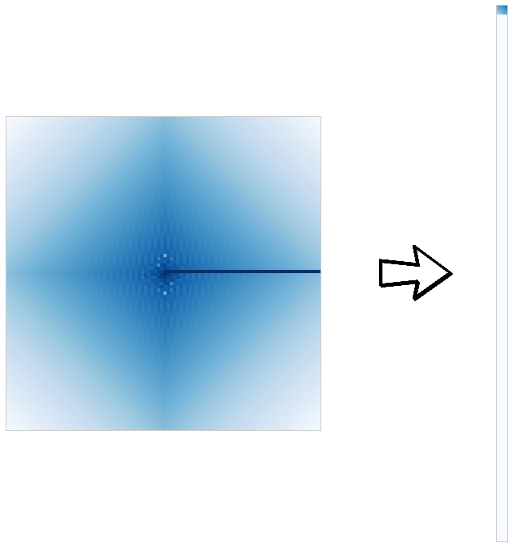

```python
import matplotlib.image as mpimg

def plot_fri_2D_images(K,n):

    gs = gridspec.GridSpec(1, 3, width_ratios=[3.85,1.5,1])

    fig = plt.figure(figsize=(12, 12), dpi=300)
    fig.patch.set_facecolor('white')
    plt.subplots_adjust(wspace = 0.05)

    tk2  = np.array([[ 0.6,  0.7], [ 0.7,  0.2], [ 0.3,  0.5]])
    tk = tk2[:,1]
    rk  = np.array([ 0.035,  0.02,   0.085])
    ck  = np.array([ 0.75,  0.7,  5.0])
    T = 1.0

    #2D VPW, 'normal'
    M = 100.0
    N = 100.0

    vpw_fri2 = VPW_FRI_2D(tk2, rk, ck, T/M, T/N)
    y_grid, x_grid = np.meshgrid(np.linspace(0, T, N),np.linspace(0, T, M))
    f_u = 2*np.pi*np.fft.fftfreq(int(M), T/M)/T
    f_v = 2*np.pi*np.fft.fftfreq(int(N), T/N)/T
    v_grid, u_grid = np.meshgrid(np.fft.fftshift(f_v), np.fft.fftshift(f_u))
    spectrum_2D = vpw_fri2.evaluate_Fourier_domain(f_u, f_v)

    n_cols = 26

    matrix = np.zeros((50*25,n_cols))
    vmax = np.max(np.abs(np.log(spectrum_2D)))
    vmin = np.min(np.abs(np.log(spectrum_2D)))

    for i in range(n):
        matrix[i*(n_cols-1):(i+1)*(n_cols-1), :] = to_toeplitz(np.abs(np.log(spectrum_2D[-i,:50])), n_cols)
    toeplitz_ax = plt.subplot(gs[0,2])
    toeplitz_ax.imshow(matrix, cmap=plt.cm.Blues, vmax=vmax, vmin=vmin)
    toeplitz_ax.set_ylabel('label text', rotation=0)
    format_2D_images(toeplitz_ax)

    spectrum_2D[-n,:50] = np.exp(vmax)

    vpw_2D_freq_ax = plt.subplot(gs[0,0])
    vpw_2D_freq_ax.matshow(np.log(np.fft.fftshift(abs(spectrum_2D))), cmap=plt.cm.Blues)
    format_2D_images(vpw_2D_freq_ax)

    #draw arrow
    arrow_ax = plt.subplot(gs[0,1])
    arrow_ax.imshow(mpimg.imread('figures/arrow.png'))
    format_2D_images(arrow_ax)
    arrow_ax.axis('off')


plot_fri_2D_images(K,1)
```

### Denoising: Cadzow

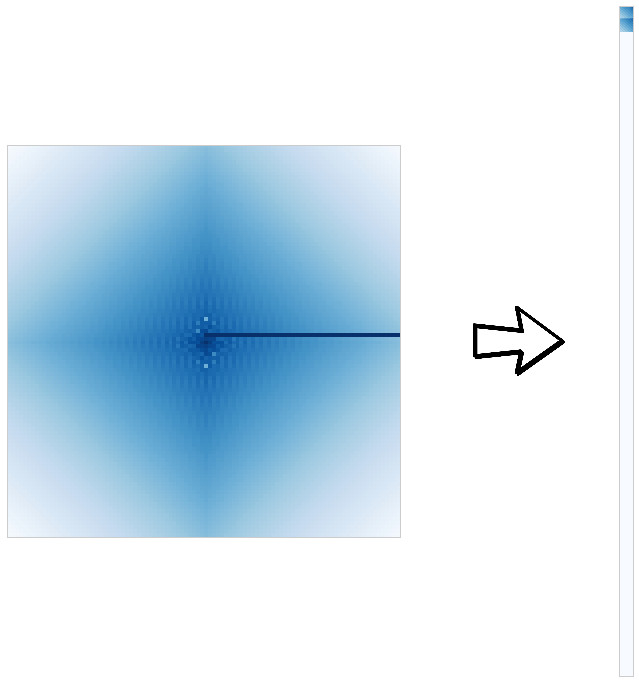

```python
plot_fri_2D_images(K,2)
```

### Denoising: Cadzow

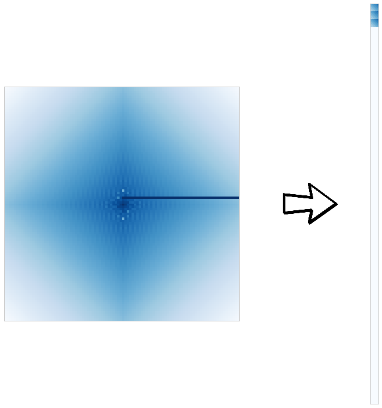

```python
plot_fri_2D_images(K,3)
```

### Denoising: Cadzow

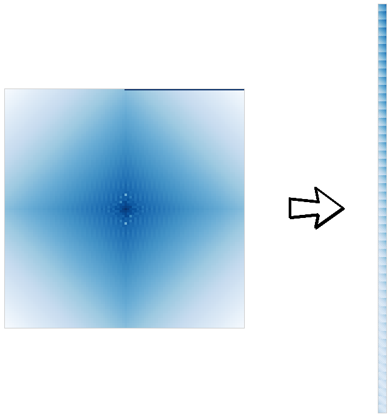

```python
plot_fri_2D_images(K,50)
```

### How about radial pulses?

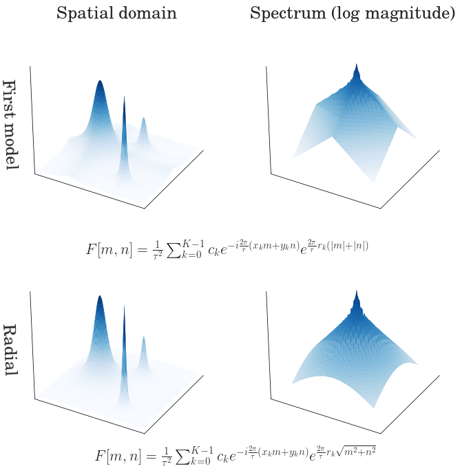

```python
from fri import *
from mpl_toolkits.mplot3d import axes3d
import matplotlib.gridspec as gridspec


def plot_fri_2D(K):

    gs = gridspec.GridSpec(2, 2)
    gs = gridspec.GridSpec(3, 2, width_ratios=[1,1], height_ratios=[10,10,0.5])

    tk2  = np.array([[ 0.6,  0.7], [ 0.7,  0.2], [ 0.3,  0.5]])
    tk = tk2[:,1]
    rk  = np.array([ 0.035,  0.02,   0.085])
    ck  = np.array([ 0.5,  0.4,  6.0])
    T = 1.0

    fig = plt.figure(figsize=(12, 12), dpi=300)
    fig.patch.set_facecolor('white')
    plt.subplots_adjust(hspace = 0.05, wspace = 0.05)

    #2D VPW, 'normal'
    M = 100.0
    N = 100.0

    vpw_fri2 = VPW_FRI_2D(tk2, rk, ck, T/M, T/N)
    y_grid, x_grid = np.meshgrid(np.linspace(0, T, N),np.linspace(0, T, M))
    f_u = 2*np.pi*np.fft.fftfreq(int(M), T/M)/T
    f_v = 2*np.pi*np.fft.fftfreq(int(N), T/N)/T
    v_grid, u_grid = np.meshgrid(np.fft.fftshift(f_v), np.fft.fftshift(f_u))
    spectrum_2D = vpw_fri2.evaluate_Fourier_domain(f_u, f_v)

    vmax = np.max(np.log(np.fft.fftshift(abs(spectrum_2D))))
    vmin = np.min(np.log(np.fft.fftshift(abs(spectrum_2D))))

    vpw_2D_freq_ax = plt.subplot(gs[0,1], projection='3d')
    vpw_2D_freq_ax.plot_surface(u_grid, v_grid, np.log(np.fft.fftshift(abs(spectrum_2D))), rstride=1, cstride=1, linewidth=0, cmap=plt.cm.Blues, vmax=vmax, vmin=vmin)
    #vpw_2D_freq_ax = plt.subplot(gs[1,1])
    #vpw_2D_freq_ax.matshow(np.log(np.fft.fftshift(abs(spectrum_2D))), cmap=plt.cm.Blues)
    format_2D(vpw_2D_freq_ax, title='Spectrum (log magnitude)')

    plt.rc('text', usetex=True)
    plt.rc('font', family='serif')
    plt.suptitle(r"$F[m,n] = \frac{1}{\tau^2} \sum_{k=0}^{K-1} c_k e^{-i \frac{2\pi}{\tau} (x_k m + y_k n)} e^{ \frac{2\pi}{\tau} r_k (|m| + |n|)}$",
          fontsize=22, x=0.5, y = 0.5)

    vpw_2D_ifft_ax = plt.subplot(gs[0,0], projection='3d')
    vpw_2D_ifft_ax.plot_surface(x_grid, y_grid, np.real(np.fft.ifft2(spectrum_2D)), rstride=1, cstride=1, linewidth=0, cmap=plt.cm.Blues)
    #vpw_2D_ifft_ax = plt.subplot(gs[1,0])
    #vpw_2D_ifft_ax.matshow(np.real(np.fft.ifft2(spectrum_2D)), cmap=plt.cm.Blues)
    format_2D(vpw_2D_ifft_ax, title='Spatial domain', label='First model')

    #2D VPW, radial
    vpw_fri3 = VPW_FRI_2D_Radial(tk2, rk, ck, T/M, T/N)

    spectrum_2D_radial = vpw_fri3.evaluate_Fourier_domain(f_u, f_v)

    vpw_2D_freq_ax_radial = plt.subplot(gs[1,1], projection='3d')
    vpw_2D_freq_ax_radial.plot_surface(u_grid, v_grid, np.log(np.fft.fftshift(abs(spectrum_2D_radial))), rstride=1, cstride=1, linewidth=0, cmap=plt.cm.Blues, vmax=vmax, vmin=vmin)
    #vpw_2D_freq_ax_radial = plt.subplot(gs[1,1])
    #vpw_2D_freq_ax_radial.matshow(np.log(np.fft.fftshift(abs(spectrum_2D))), cmap=plt.cm.Blues)
    format_2D(vpw_2D_freq_ax_radial)

    vpw_2D_ifft_ax_radial = plt.subplot(gs[1,0], projection='3d')
    vpw_2D_ifft_ax_radial.plot_surface(x_grid, y_grid, np.real(np.fft.ifft2(spectrum_2D_radial)), rstride=1, cstride=1, linewidth=0, cmap=plt.cm.Blues)
    #vpw_2D_ifft_ax_radial = plt.subplot(gs[1,0])
    #vpw_2D_ifft_ax_radial.matshow(np.real(np.fft.ifft2(spectrum_2D)), cmap=plt.cm.Blues)
    format_2D(vpw_2D_ifft_ax_radial, label='Radial')

    ax_subtitle = plt.subplot(gs[2,:])
    format_2D_images(ax_subtitle)
    ax_subtitle.set_title(r"$F[m,n] = \frac{1}{\tau^2} \sum_{k=0}^{K-1} c_k e^{-i \frac{2\pi}{\tau} (x_k m + y_k n)} e^{ \frac{2\pi}{\tau} r_k \sqrt{m^2 + n^2}}$",
          fontsize=22, x=0.5, y=-0.3)
    ax_subtitle.axis('off')



K = 3
plot_fri_2D(K)
```

### How about radial pulses?

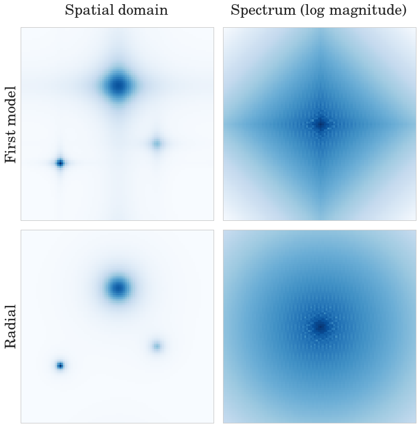

```python
from fri import *
from mpl_toolkits.mplot3d import axes3d
import matplotlib.gridspec as gridspec


def plot_fri_2D(K):

    gs = gridspec.GridSpec(2, 2)

    tk2  = np.array([[ 0.6,  0.7], [ 0.7,  0.2], [ 0.3,  0.5]])
    tk = tk2[:,1]
    rk  = np.array([ 0.035,  0.02,   0.085])
    ck  = np.array([ 0.5,  0.4,  6.0])
    T = 1.0

    fig = plt.figure(figsize=(12, 12), dpi=300)
    fig.patch.set_facecolor('white')
    plt.subplots_adjust(hspace = 0.05, wspace = 0.05)

    #2D VPW, 'normal'
    M = 100.0
    N = 100.0

    vpw_fri2 = VPW_FRI_2D(tk2, rk, ck, T/M, T/N)
    y_grid, x_grid = np.meshgrid(np.linspace(0, T, N),np.linspace(0, T, M))
    f_u = 2*np.pi*np.fft.fftfreq(int(M), T/M)/T
    f_v = 2*np.pi*np.fft.fftfreq(int(N), T/N)/T
    v_grid, u_grid = np.meshgrid(np.fft.fftshift(f_v), np.fft.fftshift(f_u))
    spectrum_2D = vpw_fri2.evaluate_Fourier_domain(f_u, f_v)

    vmax = np.max(np.log(np.fft.fftshift(abs(spectrum_2D))))
    vmin = np.min(np.log(np.fft.fftshift(abs(spectrum_2D))))

    vpw_2D_freq_ax = plt.subplot(gs[0,1])
    vpw_2D_freq_ax.matshow(np.log(np.fft.fftshift(abs(spectrum_2D))), cmap=plt.cm.Blues, vmax=vmax, vmin=vmin)
    format_2D_images(vpw_2D_freq_ax, title='Spectrum (log magnitude)',  label='')

    vpw_2D_ifft_ax = plt.subplot(gs[0,0])
    vpw_2D_ifft_ax.matshow(np.real(np.fft.ifft2(spectrum_2D)), cmap=plt.cm.Blues)
    format_2D_images(vpw_2D_ifft_ax, title='Spatial domain', label='First model')

    #2D VPW, radial
    vpw_fri3 = VPW_FRI_2D_Radial(tk2, rk, ck, T/M, T/N)

    spectrum_2D_radial = vpw_fri3.evaluate_Fourier_domain(f_u, f_v)

    vpw_2D_freq_ax_radial = plt.subplot(gs[1,1])
    vpw_2D_freq_ax_radial.matshow(np.log(np.fft.fftshift(abs(spectrum_2D_radial))), cmap=plt.cm.Blues, vmax=vmax, vmin=vmin)
    format_2D_images(vpw_2D_freq_ax_radial, label='')

    vpw_2D_ifft_ax_radial = plt.subplot(gs[1,0])
    vpw_2D_ifft_ax_radial.matshow(np.real(np.fft.ifft2(spectrum_2D_radial)), cmap=plt.cm.Blues)
    format_2D_images(vpw_2D_ifft_ax_radial, label='Radial')

K = 3
plot_fri_2D(K)
```

### How about radial pulses?

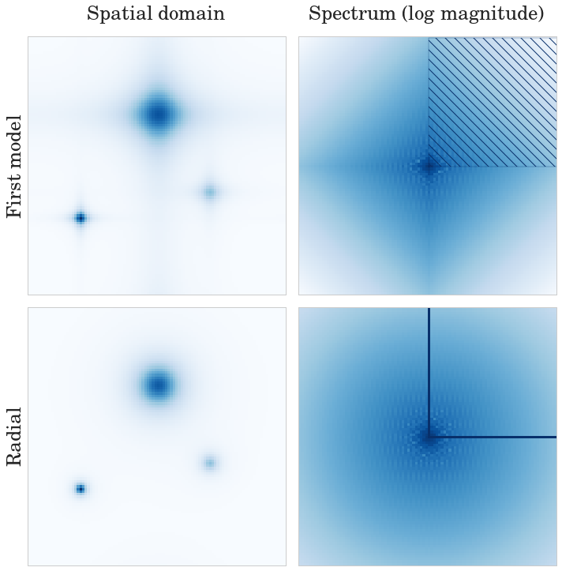

```python
import matplotlib.patches as patches


def plot_fri_2D(K):

    gs = gridspec.GridSpec(2, 2)

    tk2  = np.array([[ 0.6,  0.7], [ 0.7,  0.2], [ 0.3,  0.5]])
    tk = tk2[:,1]
    rk  = np.array([ 0.035,  0.02,   0.085])
    #ck  = np.array([ 0.75,  0.7,  5.0])
    ck  = np.array([ 0.5,  0.4,  6.0])
    T = 1.0

    fig = plt.figure(figsize=(12, 12), dpi=300)
    fig.patch.set_facecolor('white')
    plt.subplots_adjust(hspace = 0.05, wspace = 0.05)

    #2D VPW, 'normal'
    M = 100.0
    N = 100.0

    vpw_fri2 = VPW_FRI_2D(tk2, rk, ck, T/M, T/N)
    y_grid, x_grid = np.meshgrid(np.linspace(0, T, N),np.linspace(0, T, M))
    f_u = 2*np.pi*np.fft.fftfreq(int(M), T/M)/T
    f_v = 2*np.pi*np.fft.fftfreq(int(N), T/N)/T
    v_grid, u_grid = np.meshgrid(np.fft.fftshift(f_v), np.fft.fftshift(f_u))
    spectrum_2D = vpw_fri2.evaluate_Fourier_domain(f_u, f_v)

    vmax = np.max(np.log(np.fft.fftshift(abs(spectrum_2D))))
    vmin = np.min(np.log(np.fft.fftshift(abs(spectrum_2D))))

    vpw_2D_freq_ax = plt.subplot(gs[0,1])
    vpw_2D_freq_ax.matshow(np.log(np.fft.fftshift(abs(spectrum_2D))), cmap=plt.cm.Blues, vmax=vmax, vmin=vmin)
    format_2D_images(vpw_2D_freq_ax,  title='Spectrum (log magnitude)', label='')

    vpw_2D_ifft_ax = plt.subplot(gs[0,0])
    vpw_2D_ifft_ax.matshow(np.real(np.fft.ifft2(spectrum_2D)), cmap=plt.cm.Blues)
    format_2D_images(vpw_2D_ifft_ax,  title='Spatial domain', label='First model')

    p = patches.Rectangle((50, 0), 50, 50, hatch='\\\\', fill=False, edgecolor='#08306b')
    vpw_2D_freq_ax.add_patch(p)

    #2D VPW, radial
    vpw_fri3 = VPW_FRI_2D_Radial(tk2, rk, ck, T/M, T/N)

    spectrum_2D_radial = vpw_fri3.evaluate_Fourier_domain(f_u, f_v)

    vpw_2D_ifft_ax_radial = plt.subplot(gs[1,0])
    vpw_2D_ifft_ax_radial.matshow(np.real(np.fft.ifft2(spectrum_2D_radial)), cmap=plt.cm.Blues)
    format_2D_images(vpw_2D_ifft_ax_radial, label='Radial')

    spectrum_2D_radial[0,:50] = np.exp(vmax)
    spectrum_2D_radial[50:,0] = np.exp(vmax)

    vpw_2D_freq_ax_radial = plt.subplot(gs[1,1])
    vpw_2D_freq_ax_radial.matshow(np.log(np.fft.fftshift(abs(spectrum_2D_radial))), cmap=plt.cm.Blues, vmax=vmax, vmin=vmin)
    format_2D_images(vpw_2D_freq_ax_radial, label='')


K = 3
plot_fri_2D(K)
```

### Simulation: 2D model

- $K = 3$
- We use $20 \times 20$ Fourier coefficients

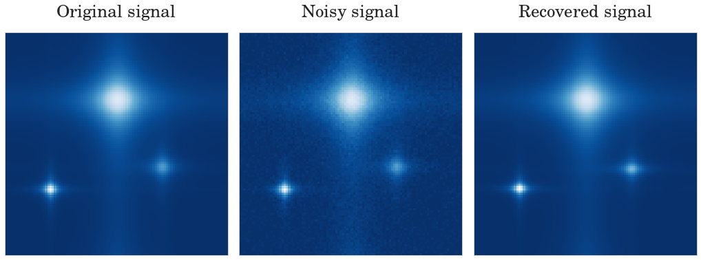

```python
from fri import *


def plot_fri_noise_2D(snr):

    gs = gridspec.GridSpec(1, 3)

    tk2  = np.array([[ 0.6,  0.7], [ 0.7,  0.2], [ 0.3,  0.5]])
    rk  = np.array([ 0.035,  0.02,   0.085])
    #ck  = np.array([ 0.75,  0.7,  5.0])
    ck  = np.array([ 0.5,  0.4,  6.0])
    T = 1.0
    K = 3

    fig = plt.figure(figsize=(18, 6), dpi=300)
    fig.patch.set_facecolor('white')
    plt.subplots_adjust(hspace = 0.05, wspace = 0.05)

    #2D VPW, 'normal'
    M = 100.0
    N = 100.0

    vpw_fri2 = VPW_FRI_2D(tk2, rk, ck, T/M, T/N)
    y_grid, x_grid = np.meshgrid(np.linspace(0, T, N),np.linspace(0, T, M))
    f_u = 2*np.pi*np.fft.fftfreq(int(M), T/M)/T
    f_v = 2*np.pi*np.fft.fftfreq(int(N), T/N)/T
    v_grid, u_grid = np.meshgrid(np.fft.fftshift(f_v), np.fft.fftshift(f_u))
    spectrum_2D = vpw_fri2.evaluate_Fourier_domain(f_u, f_v)

    signal_2D = np.real(np.fft.ifft2(spectrum_2D))

    vmax = np.max(signal_2D)
    vmin = np.min(signal_2D)

    signal_power = np.linalg.norm(signal_2D)**2/(M*N)
    noise_power  = signal_power/np.power(10, snr/10.0)

    signal_noisy   = signal_2D + np.random.normal(0,sqrt(noise_power),(int(M), int(N)))
    spectrum_noisy = np.fft.fft2(signal_noisy)

    n_coeffs = 20

    fri_estimated = FRI_estimator(K, T, T/N, T/N).estimate_parameters_2D_multi_rows(spectrum_noisy[:n_coeffs, :n_coeffs], f_u[:n_coeffs], f_v[:n_coeffs])
    signal_estimated =  np.real(np.fft.ifft2(fri_estimated.evaluate_Fourier_domain(f_u, f_v)))

    vpw_2D_ax = plt.subplot(gs[0,0])
    vpw_2D_ax.matshow(signal_2D, cmap=plt.cm.Blues_r)
    format_2D_images(vpw_2D_ax, title='Original signal')
    #vpw_2D_ax = plt.subplot(gs[0,0], projection='3d')
    #vpw_2D_ax.plot_surface(x_grid, y_grid, signal_2D, rstride=1, cstride=1, linewidth=0, cmap=plt.cm.Blues)
    #format_2D(vpw_2D_ax, title='Original signal')

    vpw_2D_noisy = plt.subplot(gs[0,1])
    vpw_2D_noisy.matshow(signal_noisy, cmap=plt.cm.Blues_r, vmin=vmin, vmax=vmax)
    format_2D_images(vpw_2D_noisy, title='Noisy signal')
    #vpw_2D_noisy = plt.subplot(gs[0,1], projection='3d')
    #vpw_2D_noisy.plot_surface(x_grid, y_grid, signal_noisy, rstride=1, cstride=1, linewidth=0, cmap=plt.cm.Blues, vmin=vmin, vmax=vmax)
    #format_2D(vpw_2D_noisy, title='Noisy signal')

    vpw_2D_rec = plt.subplot(gs[0,2])
    vpw_2D_rec.matshow(signal_estimated, cmap=plt.cm.Blues_r, vmin=vmin, vmax=vmax)
    format_2D_images(vpw_2D_rec, title='Recovered signal')


interact(plot_fri_noise_2D, snr=(-10,50));
```

### Simulation: 2D radial model

- $K = 3$
- We use $2 \times 40$ Fourier coefficients

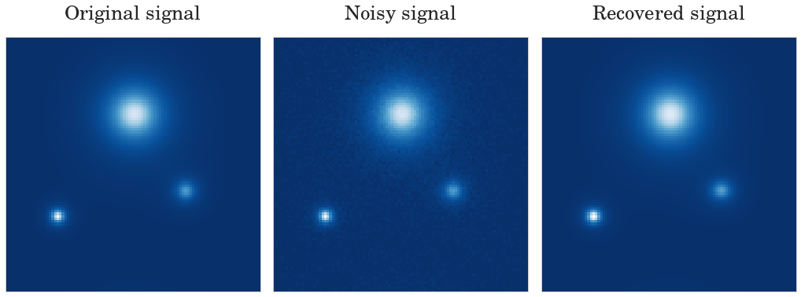

```python
from fri import *


def plot_fri_noise_2D(snr):

    gs = gridspec.GridSpec(1, 3)

    tk2  = np.array([[ 0.6,  0.7], [ 0.7,  0.2], [ 0.3,  0.5]])
    rk  = np.array([ 0.035,  0.02,   0.085])
    #ck  = np.array([ 0.75,  0.7,  5.0])
    ck  = np.array([ 0.5,  0.4,  6.0])
    T = 1.0
    K = 3

    fig = plt.figure(figsize=(18, 6), dpi=300)
    fig.patch.set_facecolor('white')
    plt.subplots_adjust(hspace = 0.05, wspace = 0.05)

    #2D VPW, 'normal'
    M = 100.0
    N = 100.0

    vpw_fri2 = VPW_FRI_2D_Radial(tk2, rk, ck, T/M, T/N)
    y_grid, x_grid = np.meshgrid(np.linspace(0, T, N),np.linspace(0, T, M))
    f_u = 2*np.pi*np.fft.fftfreq(int(M), T/M)/T
    f_v = 2*np.pi*np.fft.fftfreq(int(N), T/N)/T
    v_grid, u_grid = np.meshgrid(np.fft.fftshift(f_v), np.fft.fftshift(f_u))
    spectrum_2D = vpw_fri2.evaluate_Fourier_domain(f_u, f_v)

    signal_2D = np.real(np.fft.ifft2(spectrum_2D))

    vmax = np.max(signal_2D)
    vmin = np.min(signal_2D)

    signal_power = np.linalg.norm(signal_2D)**2/(M*N)
    noise_power  = signal_power/np.power(10, snr/10.0)

    signal_noisy   = signal_2D + np.random.normal(0,sqrt(noise_power),(int(M), int(N)))
    spectrum_noisy = np.fft.fft2(signal_noisy)

    n_coeffs = 40

    fri_est = FRI_estimator(K, T, T/N, T/N).estimate_parameters_2D_single_row(spectrum_noisy[:n_coeffs, :n_coeffs], f_u[:n_coeffs], f_v[:n_coeffs])
    fri_estimated = VPW_FRI_2D_Radial(fri_est.tk, fri_est.rk, fri_est.ck, T/M, T/N)
    signal_estimated =  np.real(np.fft.ifft2(fri_estimated.evaluate_Fourier_domain(f_u, f_v)))

    vpw_2D_ax = plt.subplot(gs[0,0])
    vpw_2D_ax.matshow(signal_2D, cmap=plt.cm.Blues_r)
    format_2D_images(vpw_2D_ax, title='Original signal')
    #vpw_2D_ax = plt.subplot(gs[0,0], projection='3d')
    #vpw_2D_ax.plot_surface(x_grid, y_grid, signal_2D, rstride=1, cstride=1, linewidth=0, cmap=plt.cm.Blues)
    #format_2D(vpw_2D_ax, title='Original signal')

    vpw_2D_noisy = plt.subplot(gs[0,1])
    vpw_2D_noisy.matshow(signal_noisy, cmap=plt.cm.Blues_r, vmin=vmin, vmax=vmax)
    format_2D_images(vpw_2D_noisy, title='Noisy signal')
    #vpw_2D_noisy = plt.subplot(gs[0,1], projection='3d')
    #vpw_2D_noisy.plot_surface(x_grid, y_grid, signal_noisy, rstride=1, cstride=1, linewidth=0, cmap=plt.cm.Blues, vmin=vmin, vmax=vmax)
    #format_2D(vpw_2D_noisy, title='Noisy signal')

    vpw_2D_rec = plt.subplot(gs[0,2])
    vpw_2D_rec.matshow(signal_estimated, cmap=plt.cm.Blues_r, vmin=vmin, vmax=vmax)
    format_2D_images(vpw_2D_rec, title='Recovered signal')


interact(plot_fri_noise_2D, snr=(-10,50));
```

### Conclusion

- A new pulse model for the FRI framework
- Application to ECG in the 1D case
- Generalization to 2D: two different pulses
- Adaptation of Cadzow denoising scheme

#### Future work

- Generalize the theory to spherical signals
- Experiment the 2D method on real data

\* I. Dokmanic, and Y. M. Lu, "Sampling Sparse Signals on the Sphere: Algorithms and Applications." IEEE Transactions on Signal Processing, 99, 2015

## Thank you for your attention

- Questions?

## BRDF

[figure not shown]